# Simulate effect sizes

Han Bossier

11/3/2019

## Introduction

In this report, we look at estimators for the population effect at the meta-analysis level. We generate effect sizes at the study level and then fit a random effects model. We estimate the between study heterogeneity using the DerSimonian & Laird estimator, the Hedges’ estimator and Restricted Maximum Likelihood. These estimates are used to estimate the population effect. We will increase the amount of between-study heterogeneity to see its effect on the estimates of the population effect.

## Data generating model

Consider an observed (standardized) effect $Y_i$ for study $i = 1, \ldots, K$. We assume the following model:

$$Y_i = X\beta +u_i + \varepsilon_i,$$
where
$$u_i \sim N\left(0, \sigma^{2}_*\right) \\
\varepsilon_i \sim N\left(0, \sigma^{2}_i\right).$$
Here $\beta$ represents the population effect, $X$ the design matrix at the meta-analysis level, $u$ a random effect and $\varepsilon$ a within-study error. Note that $X$ will be a vector of length $K$ with 1’s.

## Model parameters

We set $\beta = 0.9$ and let the between-study variance ($\sigma^2_*$) increase in 4 Monte-Carlo simulation settings. More particularly, we have: $\sigma^2_* \in \{0, 1, 4, 9\}$. We set the number of studies $K$ to 500.

```r
# True ES
Tes <- 0.9
# Number of studies
nstud <- 500
# X vector of 1's
X <- matrix(1, nrow = nstud)
# Between study variability
sigm2U <- c(0, 1, 4, 9)
```

```r
# Sample number of subjects
nsubS <- sample(x = 100:300, size = nstud, replace = TRUE)
  # Alternative: each study the same sample size
  #nsubS <- rep(30, nstud)
# Calculate true value for the variance
sigm2E <- NeuRRoStat::varHedgeT(g = Tes, N = nsubS)
```

> Note that we have a large number of subjects and studies which is needed to see if we have unbiased estimates.

## Model estimation

We use the **R** package `metafor` to fit the random-effects models. To esimate $\sigma^2_*$, we will use the DerSimonian & Laird esimtator, the Hedges’ estimator and a Restricted Maximimum Likelihood approach. Note that the model fitting procedure uses weights where these are the inverse of the sum of the within- and estimated between-study variability. Furthermore, we use the `NeuRRoStat` package to estimate $\sigma^2_*$ with the DerSimonian & Laird estimator. However, I checked its result and it is equal to the one using the `metafor` package.

## Monte-Carlo

### Settings

```r
# Number of simulations
nsim <- 1000
```

We loop over the 4 possible values for the between-study herogeneity. The following code in **R** is an example of one simulation iteration for one value for $\sigma^2_*$ (e.g. $j = 1$). We generate $K$ effect sizes, then calculate the within-study variance (using the formula of Hedges) of each effect size.

```r
# Generate data
Y <- X %*% Tes + rnorm(n = nstud, mean = 0, sd = sqrt(sigm2U[j])) +
  rnorm(n = nstud, mean = 0, sd = sqrt(sigm2E))

# Weights of each study
vi <- NeuRRoStat::varHedgeT(g = Y, N = nsubS)
```

### Execution

Here we run the simulation.

```r
# Empty data frame
results <- data.frame() %>%
  as_tibble()

# For loop over the simulations
for(i in 1:nsim){
  # For loop over the amount of between-study heterogeneity
  for(j in 1:length(sigm2U)){
    # Generate data
    Y <- X %*% Tes + rnorm(n = nstud, mean = 0, sd = sqrt(sigm2U[j])) +
      rnorm(n = nstud, mean = 0, sd = sqrt(sigm2E))

    # Weights of each study
    vi <- NeuRRoStat::varHedgeT(g = Y, N = nsubS)

    # Fit the model using rma + HE or REML estimator for tau2
    fitHE <- metafor::rma(yi = Y, vi = vi, method = 'HE')
    fitREML <- metafor::rma(yi = Y, vi = vi, method = 'REML')

    # Between study variability: DL estimator
    tau2_DL <- NeuRRoStat::tau(Y = Y, W = (1/vi), k = length(Y))
    # HE estimator
    tau2_HE <- c(fitHE$tau2)
    # REML estimator
    tau2_REML <- c(fitREML$tau2)

    # Weights
    W <- diag(c(1/(vi + tau2_DL)))

    # Estimate for B using various estimators for tau
    # First one = DerSimonian and Laird
    B_DL <- EstB(X = X, W = W, Y = Y)
      # controle: rma(yi = Y, vi = vi, method = 'DL') --> klopt
    # One using Hedges
    B_HE <- c(fitHE$beta)
    # One using REML
    B_REML <- c(fitREML$beta)

    # Save in data frame
    results <- data.frame('B' = c(B_DL, B_HE, B_REML),
              'TrueB' = Tes,
              'tau2' = c(tau2_DL, tau2_HE, tau2_REML),
              'TrueTau2' = sigm2U[j],
              'estimatorBS' = c('DL', 'HE', 'REML')
               ) %>% as_tibble() %>%
      bind_rows(results, .)
  }
}
```

## Results

### Estimator for population effect

We will first plot the average (over all simulations) of the estimates for $\beta$. We do this for each value of between-study variability and each of the three estimators for the latter. The dashed line corresponds to the true value of $\beta$.

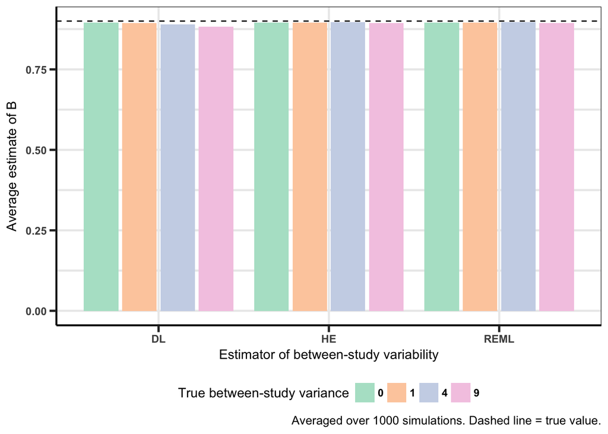

It seems to be off?

```r
results %>%
  group_by(estimatorBS, TrueTau2) %>%
  summarise(AvgEstB = mean(B),
            TrueB = mean(TrueB))
```

```
# A tibble: 12 x 4
# Groups:   estimatorBS [?]
   estimatorBS TrueTau2 AvgEstB TrueB
   <fct>          <dbl>   <dbl> <dbl>
 1 DL                 0   0.896   0.9
 2 DL                 1   0.893   0.9
 3 DL                 4   0.890   0.9
 4 DL                 9   0.883   0.9
 5 HE                 0   0.896   0.9
 6 HE                 1   0.896   0.9
 7 HE                 4   0.896   0.9
 8 HE                 9   0.894   0.9
 9 REML               0   0.896   0.9
10 REML               1   0.895   0.9
11 REML               4   0.896   0.9
12 REML               9   0.894   0.9
```

### Estimator for between-study variance

We repeat the same for the estimates of between-study variability.

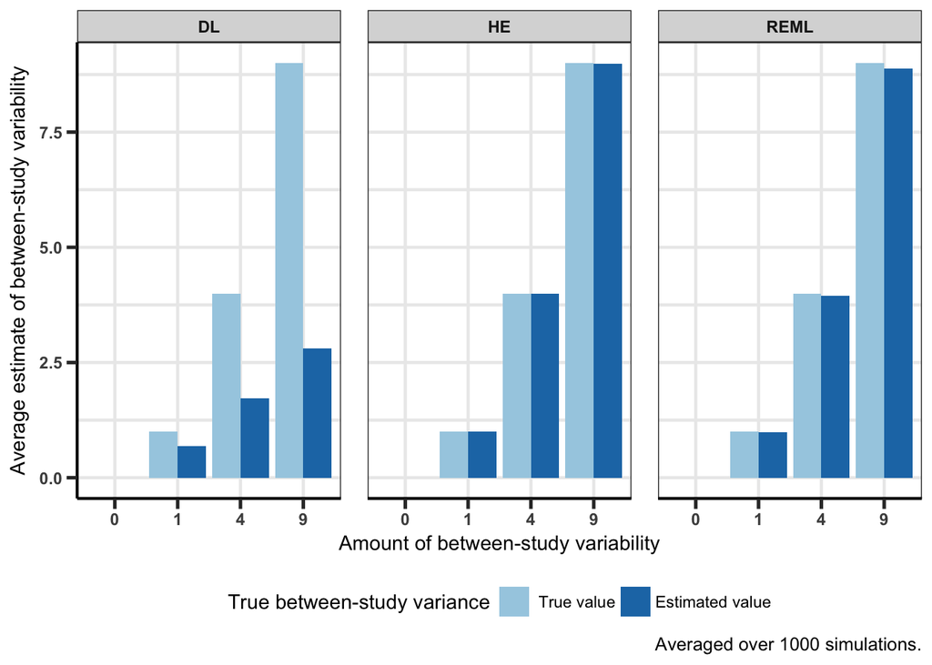

In a table, we have:

```r
results %>%
  dplyr::select(-B,-TrueB) %>%
  group_by(TrueTau2, estimatorBS) %>%
  summarise(AvgEstTau2 = mean(tau2))
```

```
# A tibble: 12 x 3
# Groups:   TrueTau2 [?]
   TrueTau2 estimatorBS AvgEstTau2
      <dbl> <fct>            <dbl>
 1        0 DL            0.000176
 2        0 HE            0.000196
 3        0 REML          0.000183
 4        1 DL            0.687
 5        1 HE            0.998
 6        1 REML          0.986
 7        4 DL            1.73
 8        4 HE            3.99
 9        4 REML          3.95
10        9 DL            2.80
11        9 HE            8.98
12        9 REML          8.88
```